# HW1

Cheng Zhong 16307110259

2019年3月8日

- **二手车保值比率影响因素分析**

狗熊会 案例难度：***

随着我国消费者消费观念的转变，购车族对于二手车的接受度和需求度大大提高，持续拉动二手车市场的发展。同时，二手车电商市场的不断升级，消费者可以直接通过电脑来选择自己满意的品牌车型，并且能直接在网上与店家谈价，进一步提高了汽车的流通速度。

谈及二手车市场，保值率可以说同时牵动买车方、卖车方、中间交易商和汽车制造商的心，那到底什么是影响二手车保值率的关键因素呢？相关方又应该如何利用这些因素，达成称心如意的二手车交易呢？本案例通过分析探究二手车的基本属性、使用状况、动力情况和内外部配置等相关因素对其保值比率的影响，并建立线性回归模型，获得影响二手车保值比率的关键因素，为各相关方提供宝贵建议。

学习目标：

1. 了解二手车保值比率相关数据；
2. 对数据进行简单处理和描述分析；
3. 对不同属性进行交互分析。
4. 建立线性回归模型并选择变量。

- **任务一**

设置好工作路径后读入二手车数据cars.csv，命名为dat0，查看数据的行数和列数。由于存在一些没有采集到关键变量的数据，而这类数据不纳入后续分析和回归建模，因此提前删除，处理后的数据命名更新后，查看数据总量。

没有采集到的关键变量特征为：

pailiang = -1 paifang = -1

```r
setwd("E:\\复旦课件\\大数据\\数据挖掘\\HW1")
dat0 <- read.csv("cars.csv", stringsAsFactors = FALSE)
#install.packages("dplyr")
#install.packages("ggplot2")
#install.packages("ggpubr")
library(dplyr)
#library(ggplot2)
#library(ggpubr)
dat1 <- dat0 %>% filter(pailiang != -1, paifang != -1)
dim(dat0)
```

```
## [1] 12951    19
```

```r
length(dat1[,1])
```

```
## [1] 12820
```

- **任务二**

绘制汽车保值率和Log-保值比率的直方图，观察数据特征，并进行简要解读（可以关注最大、最小值分别是什么类型的汽车呢？）。

注意：保值率 = 报价/原价；Log-保值比率 = Log(报价/(原价 - 报价))

```r
dat1$VPR = dat1$baojia/dat1$yuanjia
dat1$LogVPR = log(dat1$baojia/(dat1$yuanjia - dat1$baojia))
```

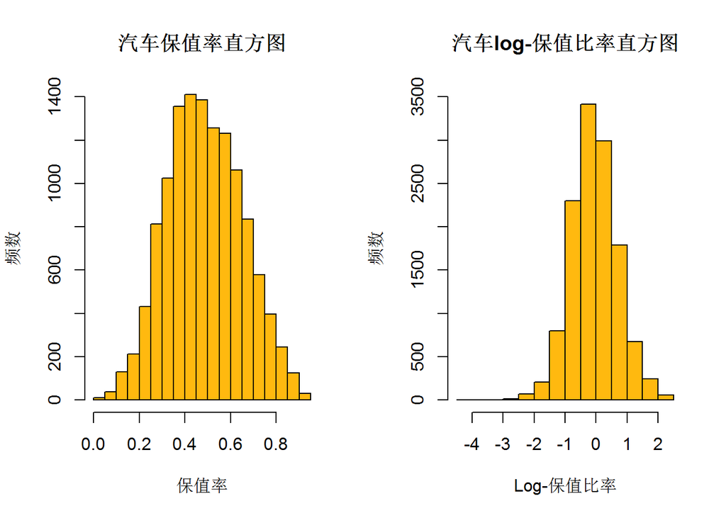

```r
par(mfrow=c(1,2))
hist(dat1$VPR,xlab = "保值率",ylab = "频数",col = "darkgoldenrod1", ylim = c(0,1400),main = "汽车保值率直方图")
hist(dat1$LogVPR,xlab = "Log-保值比率",ylab = "频数",col = "darkgoldenrod1",ylim = c(0,3500),main = "汽车log-保值比率直方图")
```

解读：通过对数据进行分析，可以发现保值率和Log-保值比率较高的汽车具有以下特征：多使用国五的排放标准,车型多为SUV车型，排量介于1.0-2.0之间，车辆里程数较小；相反的，保值率和Log-保值比率较低的汽车主要采用国三或以下的排放标准，车型多为紧凑型车，排量在1.0以下，车辆里程数大。

- **任务三**

汽车的动力情况中，排放标准和排量情况对其保值比率是否有影响呢？绘制这两个变量对Log-保值比率的箱线图，探究它们之间的关系，并给出你的解读。

注意：

不同类型的排放标准可以进行合并，保留你认为较为合适的变量水平； 汽车的排量（单位：L）情况划分为：微型轿车的排量小于1L；普通级轿车的排量为[1.0, 1.6)；中级轿车的排量为[1.6, 2.5)；中高级轿车的排量为[2.5, 4.0)；高级轿车的排量则大于等于4.0L。

```r
dat1[(dat1$pailiang >= 4),5] <- "高级轿车"
dat1[((dat1$pailiang >= 2.5)&(dat1$pailiang < 4.0)),5] <- "中高级轿车"
dat1[((dat1$pailiang >= 1.6)&(dat1$pailiang < 2.5)),5] <- "中级轿车"
dat1[((dat1$pailiang >= 1)&(dat1$pailiang < 1.6)),5] <- "普通级轿车"
dat1[(dat1$pailiang < 1),5] <- "微型轿车"
dat1[which((dat1$paifang != "国四")&(dat1$paifang != "国五")),17] <- c("国三及以下")
type = as.factor(dat1$pailiang)
type = factor(type,levels = c('微型轿车','普通级轿车','中级轿车','中高级轿车','高级轿车'))
```

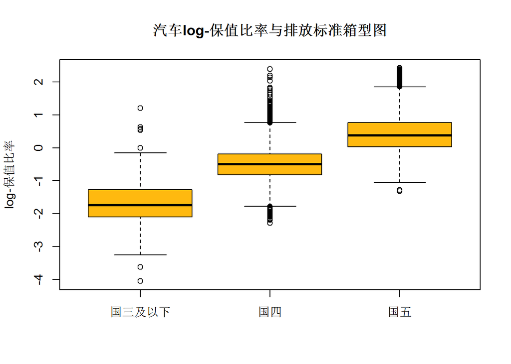

```r
boxplot(dat1$LogVPR ~ dat1$paifang, ylab = "log-保值比率",col = "darkgoldenrod1",main = "汽车log-保值比率与排放标准箱型图")
```

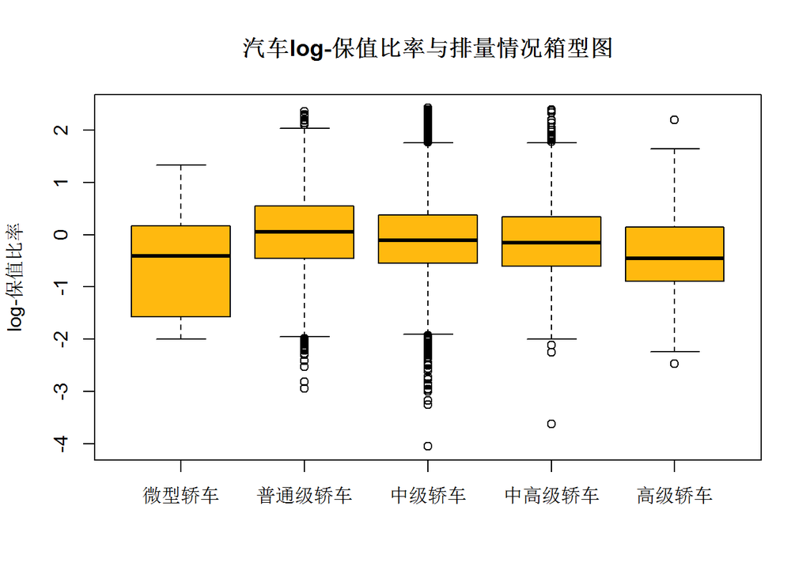

```r
boxplot(dat1$LogVPR ~ type, ylab = "log-保值比率",col = "darkgoldenrod1",main = "汽车log-保值比率与排量情况箱型图")
```

- **任务四**

根据描述分析，发现不同车身类型、不同汽车厂商的保值比率也各有所差异。进而我们想知道，不同汽车厂商的二手车中，车身类型对保值比率的影响是不同的吗？找到数据cars-final.csv，读入后命名为dat，这个数据文件对多分类变量已经进行了哑变量处理。对车身类型和汽车厂商进行交互分析，绘制箱线图，尝试给出解读。

注意：由于汽车厂商类型较多，在本数据中选择样本量较多的几种，其余的厂商合并为其他厂商。

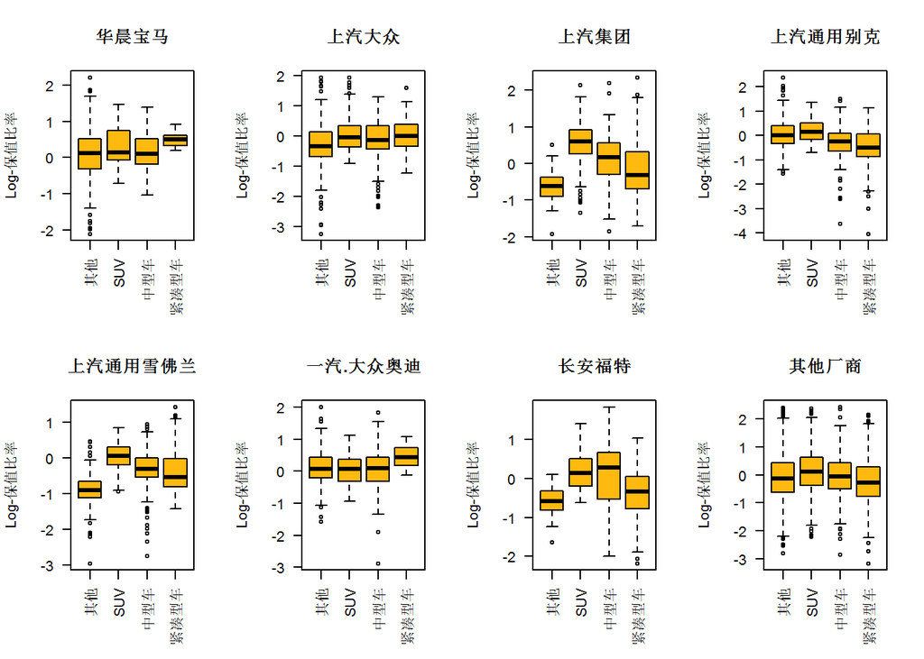

```r
dat <- read.csv("cars-final.csv", stringsAsFactors = FALSE)

dat$LogVPR = log(dat$baojia/(dat$yuanjia - dat$baojia))

dat[which((dat$SUV != 1)&(dat$中型车!= 1)&(dat$紧凑型车!= 1)),38] <- 1
dat[which(dat$SUV== 1),38] <- 2
dat[which(dat$中型车== 1),38] <- 3
dat[which(dat$紧凑型车== 1),38] <- 4

datHC <- dat %>% filter(华晨宝马 == 1)
datDZ <- dat %>% filter(上汽大众 == 1)
datJT <- dat %>% filter(上汽集团 == 1)
datBK <- dat %>% filter(上汽通用别克 == 1)
datXFL <- dat %>% filter(上汽通用雪佛兰 == 1)
datOD <- dat %>% filter(一汽.大众奥迪 == 1)
datFT <- dat %>% filter(长安福特 == 1)
datQT <- dat %>% filter(其他.1 == 1)

par(mfrow=c(2,4))
boxplot(datHC$LogVPR ~ datHC$V38, ylab = "Log-保值比率",col = "darkgoldenrod1",main = "华晨宝马", names = c("其他","SUV","中型车","紧凑型车"), par(las="2"))
boxplot(datDZ$LogVPR ~ datDZ$V38, ylab = "Log-保值比率",col = "darkgoldenrod1",main = "上汽大众", names = c("其他","SUV","中型车","紧凑型车"), par(las="2"))
boxplot(datJT$LogVPR ~ datJT$V38, ylab = "Log-保值比率",col = "darkgoldenrod1",main = "上汽集团", names = c("其他","SUV","中型车","紧凑型车"), par(las="2"))
boxplot(datBK$LogVPR ~ datBK$V38, ylab = "Log-保值比率",col = "darkgoldenrod1",main = "上汽通用别克", names = c("其他","SUV","中型车","紧凑型车"), par(las="2"))
boxplot(datXFL$LogVPR ~ datXFL$V38, ylab = "Log-保值比率",col = "darkgoldenrod1",main = "上汽通用雪佛兰", names = c("其他","SUV","中型车","紧凑型车"), par(las="2"))
boxplot(datOD$LogVPR ~ datOD$V38, ylab = "Log-保值比率",col = "darkgoldenrod1",main = "一汽.大众奥迪", names = c("其他","SUV","中型车","紧凑型车"), par(las="2"))
boxplot(datFT$LogVPR ~ datFT$V38, ylab = "Log-保值比率",col = "darkgoldenrod1",main = "长安福特", names = c("其他","SUV","中型车","紧凑型车"), par(las="2"))
boxplot(datQT$LogVPR ~ datQT$V38, ylab = "Log-保值比率",col = "darkgoldenrod1",main = "其他厂商", names = c("其他","SUV","中型车","紧凑型车"), par(las="2"))
```

- **任务五**

在任务四的结果中，我们可以看出汽车厂商和车身类型交互影响的作用是不可忽视的。此外，连续变量里程对汽车的保值比率影响又是如何的呢？绘制散点图，发现其中的规律。

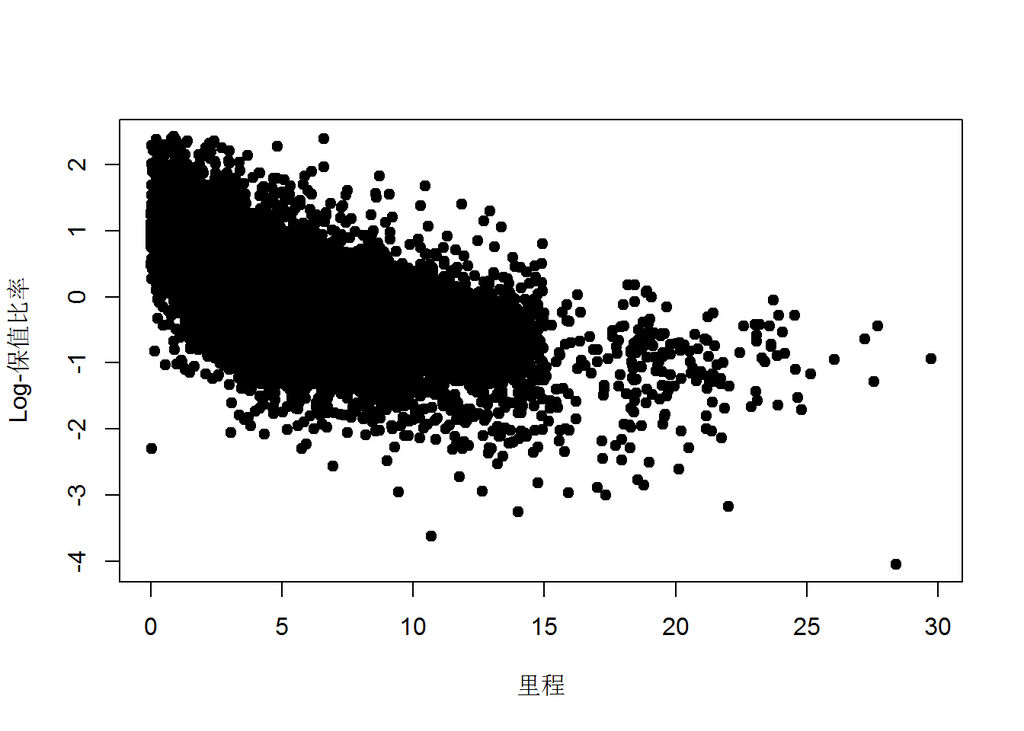

```r
par(mfrow=c(1,1))
plot(dat$licheng,dat$LogVPR,ylab = "Log-保值比率", xlab = "里程",pch = 19)
```

解读：从散点图中可以看出，总体来说里程越大的车型，保值比率越低，反之亦然。